# 06 - Other ANOVA designs part 3

Francisco E. Fonturbel

28/September/2025

## Repeated Measures ANOVA

A common task is measuring the same experimental unit at multiple times. For example, we have plants growing under three different treatments and we measure plant height as a response variable, but we measure our plant every week for two months. So, we cannot consider each measurement as an independent data point as they represent **pseudo-replicates**. Thus, we cannot run a simple one-way ANOVA with such data, but we can run a **repeated measures ANOVA** instead to correct our data indicating R that we have sampled the same experimental unit *t* times.

### Understanding the Problem

**Why not regular ANOVA?** - Measurements from the same individual are not independent - This violates the independence assumption of ANOVA - Treating repeated measures as independent inflates Type I error (false positives) - We need to account for the correlation structure within subjects

**Repeated Measures ANOVA accounts for:** - Within-subject correlation - Individual differences as a source of variation - Temporal patterns in the data

### Loading and Exploring the Data

```r
#loading packages
library(car)         # For Type II/III ANOVA
library(ggplot2)     # For advanced plotting
library(dplyr)       # For data manipulation
library(tidyr)       # For data reshaping
library(ez)          # For ezANOVA (alternative repeated measures)
library(emmeans)     # For post-hoc tests and contrasts
library(lme4)        # For mixed effects models
library(nlme)        # Alternative for mixed effects

#Let's load the data file
data<-read.table("data/06-repeated.txt", header = T)

# Convert to appropriate factors
data$id <- factor(data$id)
data$workout <- factor(data$workout)
data$diet <- factor(data$diet)
data$time <- factor(data$time)
attach(data)

# Examine data structure
str(data)
```

```
## 'data.frame':    54 obs. of  5 variables:
##  $ id     : Factor w/ 18 levels "1","2","3","4",..: 1 1 1 2 2 2 3 3 3 4 ...
##  $ workout: Factor w/ 3 levels "1","2","3": 1 1 1 1 1 1 1 1 1 1 ...
##  $ diet   : Factor w/ 2 levels "1","2": 1 1 1 1 1 1 1 1 1 2 ...
##  $ pulse  : int  93 166 215 93 166 225 89 132 195 95 ...
##  $ time   : Factor w/ 3 levels "1","2","3": 1 2 3 1 2 3 1 2 3 1 ...
```

```r
head(data, 12) # Show first 12 rows to see multiple time points per subject
```

```
##    id workout diet pulse time
## 1   1       1    1    93    1
## 2   1       1    1   166    2
## 3   1       1    1   215    3
## 4   2       1    1    93    1
## 5   2       1    1   166    2
## 6   2       1    1   225    3
## 7   3       1    1    89    1
## 8   3       1    1   132    2
## 9   3       1    1   195    3
## 10  4       1    2    95    1
## 11  4       1    2   134    2
## 12  4       1    2   186    3
```

### Exploratory Data Analysis

Let’s explore our data structure and patterns:

```r
# Check experimental design balance
table(data$workout, data$diet)
```

```
##
##     1 2
##   1 9 9
##   2 9 9
##   3 9 9
```

```r
table(data$id, data$time) # Each subject should appear once per time point
```

```
##
##      1 2 3
##   1  1 1 1
##   2  1 1 1
##   3  1 1 1
##   4  1 1 1
##   5  1 1 1
##   6  1 1 1
##   7  1 1 1
##   8  1 1 1
##   9  1 1 1
##   10 1 1 1
##   11 1 1 1
##   12 1 1 1
##   13 1 1 1
##   14 1 1 1
##   15 1 1 1
##   16 1 1 1
##   17 1 1 1
##   18 1 1 1
```

```r
# Summary statistics by groups and time
data %>%
  group_by(workout, diet, time) %>%
  summarise(
    n = n(),
    mean_pulse = mean(pulse),
    sd_pulse = sd(pulse),
    se_pulse = sd(pulse)/sqrt(n()),
    .groups = 'drop'
  )
```

```
## # A tibble: 18 × 7
##    workout diet  time      n mean_pulse sd_pulse se_pulse
##    <fct>   <fct> <fct> <int>      <dbl>    <dbl>    <dbl>
##  1 1       1     1         3       91.7     2.31     1.33
##  2 1       1     2         3      155.     19.6     11.3
##  3 1       1     3         3      212.     15.3      8.82
##  4 1       2     1         3       76.7    15.9      9.21
##  5 1       2     2         3      121.     12.6      7.26
##  6 1       2     3         3      171      18.7     10.8
##  7 2       1     1         3       93.3     7.23     4.18
##  8 2       1     2         3      144.     30.6     17.6
##  9 2       1     3         3      210.     27.6     15.9
## 10 2       2     1         3       82.7     8.96     5.17
## 11 2       2     2         3      131.     17.7     10.2
## 12 2       2     3         3      189.     24.1     13.9
## 13 3       1     1         3       85.7     4.04     2.33
## 14 3       1     2         3      141.     13.6      7.84
## 15 3       1     3         3      209.     13.1      7.54
## 16 3       2     1         3       73.7    14.0      8.09
## 17 3       2     2         3      114.     16.8      9.70
## 18 3       2     3         3      160.     27.7     16.0
```

```r
# Check for missing values
sum(is.na(data$pulse))
```

```
## [1] 0
```

```r
# Individual subject trajectories
data %>%
  group_by(id) %>%
  summarise(
    workout = first(workout),
    diet = first(diet),
    n_timepoints = n(),
    mean_pulse = mean(pulse),
    .groups = 'drop'
  ) %>%
  head(10)
```

```
## # A tibble: 10 × 5
##    id    workout diet  n_timepoints mean_pulse
##    <fct> <fct>   <fct>        <int>      <dbl>
##  1 1     1       1                3       158
##  2 2     1       1                3       161.
##  3 3     1       1                3       139.
##  4 4     1       2                3       138.
##  5 5     1       2                3       108.
##  6 6     1       2                3       122.
##  7 7     2       1                3       172
##  8 8     2       1                3       130.
##  9 9     2       1                3       144.
## 10 10    2       2                3       154.
```

### Visualization of Repeated Measures Data

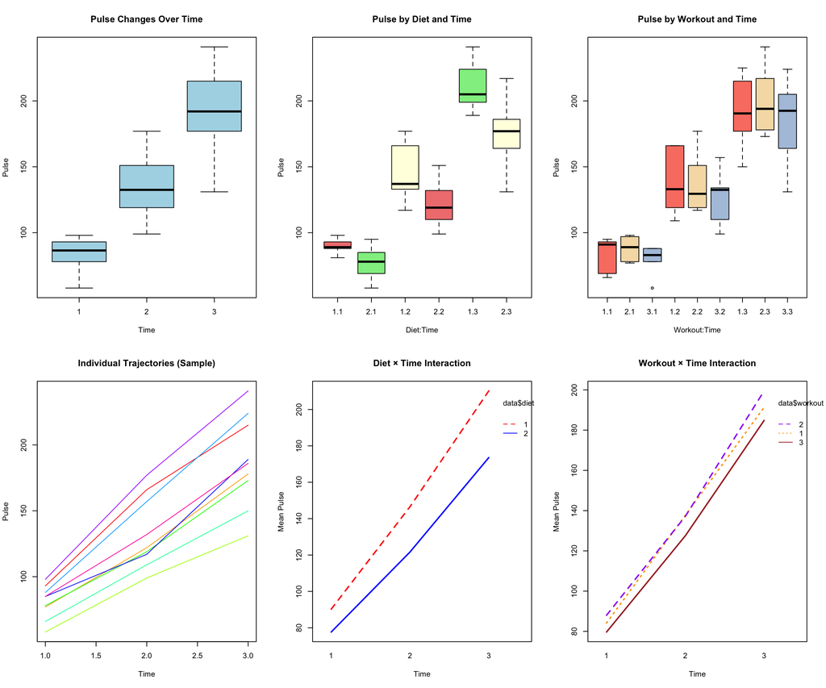

```r
# Create comprehensive visualization
par(mfrow=c(2,3))

# 1. Overall time trend
boxplot(pulse ~ time, data = data,
        main = "Pulse Changes Over Time",
        xlab = "Time", ylab = "Pulse",
        col = "lightblue")

# 2. Diet effects over time
boxplot(pulse ~ diet:time, data = data,
        main = "Pulse by Diet and Time",
        xlab = "Diet:Time", ylab = "Pulse",
        col = c("lightcoral", "lightgreen", "lightyellow"))

# 3. Workout effects over time
boxplot(pulse ~ workout:time, data = data,
        main = "Pulse by Workout and Time",
        xlab = "Workout:Time", ylab = "Pulse",
        col = c("salmon", "wheat", "lightsteelblue"))

# 4. Individual trajectories (sample)
sample_ids <- sample(unique(data$id), 9)
plot(1, type="n", xlim=c(1,3), ylim=range(data$pulse),
     main = "Individual Trajectories (Sample)",
     xlab = "Time", ylab = "Pulse")
for(i in sample_ids) {
  subject_data <- data[data$id == i, ]
  lines(as.numeric(subject_data$time), subject_data$pulse,
        col = rainbow(length(sample_ids))[which(sample_ids == i)])
}

# 5. Diet interaction plot
interaction.plot(data$time, data$diet, data$pulse,
                main = "Diet × Time Interaction",
                xlab = "Time", ylab = "Mean Pulse",
                col = c("red", "blue", "green"), lwd = 2)

# 6. Workout interaction plot
interaction.plot(data$time, data$workout, data$pulse,
                main = "Workout × Time Interaction",
                xlab = "Time", ylab = "Mean Pulse",
                col = c("orange", "purple", "brown"), lwd = 2)
```

```r
par(mfrow=c(1,1))
```

### Traditional Repeated Measures ANOVA

Let’s fit a repeated measures ANOVA model with this:

```r
rm.aov <- aov(pulse ~ diet * workout * time + Error(id))
```

OK, now we have an object called `rm.aov`, now we’ll use the `summary()` function to see the results:

```r
summary(rm.aov)
```

```
##
## Error: id
##              Df Sum Sq Mean Sq F value  Pr(>F)
## diet          1   8239    8239  10.508 0.00707 **
## workout       2   1098     549   0.700 0.51559
## diet:workout  2    680     340   0.434 0.65780
## Residuals    12   9408     784
## ---
## Signif. codes:  0 '***' 0.001 '**' 0.01 '*' 0.05 '.' 0.1 ' ' 1
##
## Error: Within
##                   Df Sum Sq Mean Sq F value  Pr(>F)
## time               2 105042   52521 618.230 < 2e-16 ***
## diet:time          2   1308     654   7.700 0.00261 **
## workout:time       4    153      38   0.449 0.77173
## diet:workout:time  4    335      84   0.986 0.43407
## Residuals         24   2039      85
## ---
## Signif. codes:  0 '***' 0.001 '**' 0.01 '*' 0.05 '.' 0.1 ' ' 1
```

Our results show that diet had a **significant effect** on athletes’ pulse, but not workout scheme or the interaction of both. Further, the repeated measures showed that pulse changed over time and this change was related to diet (significant diet:time interaction).

### Alternative Analysis with ezANOVA

The `ez` package provides a more comprehensive approach to repeated measures ANOVA:

```r
# Using ezANOVA for more detailed output
ez_result <- ezANOVA(
  data = data,
  dv = pulse,
  wid = id,
  within = time,
  between = c(diet, workout),
  detailed = TRUE,
  return_aov = TRUE
)

print(ez_result)
```

```
## $ANOVA
##              Effect DFn DFd          SSn      SSd            F            p
## 1       (Intercept)   1  12 1008326.6852 9408.444 1286.0702206 1.413638e-13
## 2              diet   1  12    8238.6852 9408.444   10.5080306 7.065519e-03
## 3           workout   2  12    1098.2593 9408.444    0.7003874 5.155942e-01
## 5              time   2  24  105041.8148 2038.889  618.2297548 2.270848e-21
## 4      diet:workout   2  12     680.2593 9408.444    0.4338183 6.578013e-01
## 6         diet:time   2  24    1308.2593 2038.889    7.6998365 2.609898e-03
## 7      workout:time   4  24     152.7407 2038.889    0.4494823 7.717267e-01
## 8 diet:workout:time   4  24     334.9630 2038.889    0.9857221 4.340684e-01
##   p<.05        ges
## 1     * 0.98877464
## 2     * 0.41850439
## 3       0.08754144
## 5     * 0.90173047
## 4       0.05609186
## 6     * 0.10256358
## 7       0.01316722
## 8       0.02842934
##
## $`Mauchly's Test for Sphericity`
##              Effect        W          p p<.05
## 5              time 0.574177 0.04728811     *
## 6         diet:time 0.574177 0.04728811     *
## 7      workout:time 0.574177 0.04728811     *
## 8 diet:workout:time 0.574177 0.04728811     *
##
## $`Sphericity Corrections`
##              Effect       GGe        p[GG] p[GG]<.05       HFe        p[HF]
## 5              time 0.7013493 1.347344e-15         * 0.7660008 7.552255e-17
## 6         diet:time 0.7013493 7.891118e-03         * 0.7660008 6.200826e-03
## 7      workout:time 0.7013493 7.087534e-01           0.7660008 7.245094e-01
## 8 diet:workout:time 0.7013493 4.185226e-01           0.7660008 4.225992e-01
##   p[HF]<.05
## 5         *
## 6         *
## 7
## 8
##
## $aov
```

[output cut: 11 more lines]

```
## Deg. of Freedom        1        2            2        12
##
## Residual standard error: 28.00066
## 10 out of 15 effects not estimable
## Estimated effects may be unbalanced
##
## Stratum 2: id:time
##
## Terms:
##                      time diet:time workout:time diet:workout:time Residuals
## Sum of Squares  105041.81   1308.26       152.74            334.96   2038.89
## Deg. of Freedom         2         2            4                 4        24
##
## Residual standard error: 9.217033
## Estimated effects may be unbalanced
```

### Checking Assumptions

Repeated measures ANOVA has specific assumptions we need to check:

```r
# 1. Sphericity assumption (compound symmetry)
# Extract the within-subject model for sphericity testing
within_model <- aov(pulse ~ time + Error(id/time), data = data)

# 2. Check residuals for normality and homogeneity
residuals_rm <- residuals(lm(pulse ~ diet * workout * time + id, data = data))

par(mfrow=c(2,2))
hist(residuals_rm, main = "Distribution of Residuals", col = "lightblue")
qqnorm(residuals_rm, main = "Q-Q Plot of Residuals")
qqline(residuals_rm)
plot(fitted(lm(pulse ~ diet * workout * time + id, data = data)), residuals_rm,
     main = "Residuals vs Fitted", xlab = "Fitted Values", ylab = "Residuals")
abline(h = 0, col = "red")

# Test for normality
shapiro.test(residuals_rm)
```

```
##
##  Shapiro-Wilk normality test
##
## data:  residuals_rm
## W = 0.97654, p-value = 0.3665
```

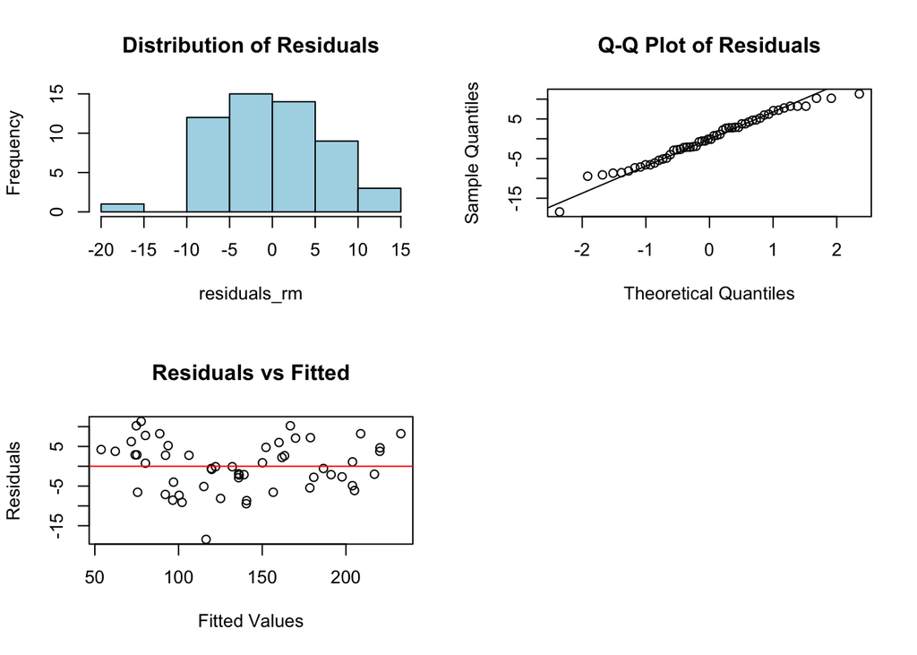

```r
par(mfrow=c(1,1))
```

### Mixed Effects Models (Advanced Alternative)

Modern approaches often use mixed effects models instead of traditional repeated measures ANOVA:

```r
# Fit mixed effects model
library(lme4)
mixed_model <- lmer(pulse ~ diet * workout * time + (1|id), data = data)
summary(mixed_model)
```

```
## Linear mixed model fit by REML ['lmerMod']
## Formula: pulse ~ diet * workout * time + (1 | id)
##    Data: data
##
## REML criterion at convergence: 308.5
##
## Scaled residuals:
##      Min       1Q   Median       3Q      Max
## -1.72943 -0.51664  0.03846  0.52447  1.38075
##
## Random effects:
##  Groups   Name        Variance Std.Dev.
##  id       (Intercept) 233.03   15.265
##  Residual              84.95    9.217
## Number of obs: 54, groups:  id, 18
##
## Fixed effects:
##                      Estimate Std. Error t value
## (Intercept)            91.667     10.295   8.904
## diet2                 -15.000     14.560  -1.030
## workout2                1.667     14.560   0.114
## workout3               -6.000     14.560  -0.412
## time2                  63.000      7.526   8.371
## time3                 120.000      7.526  15.945
## diet2:workout2          4.333     20.591   0.210
## diet2:workout3          3.000     20.591   0.146
## diet2:time2           -19.000     10.643  -1.785
## diet2:time3           -25.667     10.643  -2.412
## workout2:time2        -12.667     10.643  -1.190
## workout3:time2         -7.333     10.643  -0.689
## workout2:time3         -3.667     10.643  -0.345
## workout3:time3          3.667     10.643   0.345
## diet2:workout2:time2   16.667     15.051   1.107
## diet2:workout3:time2    3.333     15.051   0.221
## diet2:workout2:time3   16.000     15.051   1.063
## diet2:workout3:time3  -11.333     15.051  -0.753
```

```r
# Type III ANOVA table for mixed model
Anova(mixed_model, type = "III")
```

```
## Analysis of Deviance Table (Type III Wald chisquare tests)
##
## Response: pulse
##                      Chisq Df Pr(>Chisq)
## (Intercept)        79.2761  1    < 2e-16 ***
## diet                1.0614  1    0.30290
## workout             0.3068  2    0.85779
## time              254.4680  2    < 2e-16 ***
## diet:workout        0.0465  2    0.97703
## diet:time           6.2635  2    0.04364 *
## workout:time        2.0769  4    0.72161
## diet:workout:time   3.9429  4    0.41379
## ---
## Signif. codes:  0 '***' 0.001 '**' 0.01 '*' 0.05 '.' 0.1 ' ' 1
```

```r
# Compare with traditional ANOVA
print("Traditional RM-ANOVA vs Mixed Effects Model comparison:")
```

```
## [1] "Traditional RM-ANOVA vs Mixed Effects Model comparison:"
```

```r
print("Both approaches account for repeated measures but mixed models are more flexible")
```

```
## [1] "Both approaches account for repeated measures but mixed models are more flexible"
```

### Post-hoc Analysis

Since we found significant effects, let’s conduct post-hoc tests:

```r
# Method 1: Fit separate models for post-hoc tests
# For main effects that don't involve the repeated measure
if(any(grepl("diet", names(summary(rm.aov))))) {
  diet_model <- aov(pulse ~ diet + Error(id), data = data)
  # Extract the between-subjects part for Tukey test
  diet_simple <- aov(pulse ~ diet, data = aggregate(pulse ~ id + diet, data, mean))
  print("Post-hoc test for diet effect:")
  TukeyHSD(diet_simple)
}

# Method 2: Using emmeans for more control (recommended approach)
library(emmeans)

# Create a linear model including subject as a factor for emmeans
lm_model <- lm(pulse ~ diet * workout * time + id, data = data)

# Main effect of diet
diet_means <- emmeans(lm_model, ~ diet)
print("Pairwise comparisons for diet:")
```

```
## [1] "Pairwise comparisons for diet:"
```

```r
pairs(diet_means)
```

```
##  contrast      estimate   SE df t.ratio p.value
##  diet1 - diet2     24.7 2.51 24   9.848 <0.0001
##
## Results are averaged over the levels of: time, id, workout
```

```r
# If time effect is significant, examine time comparisons
time_means <- emmeans(lm_model, ~ time)
print("Pairwise comparisons for time:")
```

```
## [1] "Pairwise comparisons for time:"
```

```r
pairs(time_means)
```

```
##  contrast      estimate   SE df t.ratio p.value
##  time1 - time2    -50.2 3.07 24 -16.328 <0.0001
##  time1 - time3   -107.9 3.07 24 -35.134 <0.0001
##  time2 - time3    -57.8 3.07 24 -18.806 <0.0001
##
## Results are averaged over the levels of: id, diet, workout
## P value adjustment: tukey method for comparing a family of 3 estimates
```

```r
# Diet × Time interaction (if significant)
diet_time_means <- emmeans(lm_model, ~ diet * time)
print("Diet effects at each time point:")
```

```
## [1] "Diet effects at each time point:"
```

```r
pairs(diet_time_means, by = "time")
```

```
## time = 1:
##  contrast      estimate   SE df t.ratio p.value
##  diet1 - diet2     12.6 4.34 24   2.890  0.0081
##
## time = 2:
##  contrast      estimate   SE df t.ratio p.value
##  diet1 - diet2     24.9 4.34 24   5.728 <0.0001
##
## time = 3:
##  contrast      estimate   SE df t.ratio p.value
##  diet1 - diet2     36.7 4.34 24   8.439 <0.0001
##
## Results are averaged over the levels of: id, workout
```

```r
print("Time effects within each diet:")
```

```
## [1] "Time effects within each diet:"
```

```r
pairs(diet_time_means, by = "diet")
```

```
## diet = 1:
##  contrast      estimate   SE df t.ratio p.value
##  time1 - time2    -56.3 4.34 24 -12.965 <0.0001
##  time1 - time3   -120.0 4.34 24 -27.618 <0.0001
##  time2 - time3    -63.7 4.34 24 -14.653 <0.0001
##
## diet = 2:
##  contrast      estimate   SE df t.ratio p.value
##  time1 - time2    -44.0 4.34 24 -10.127 <0.0001
##  time1 - time3    -95.9 4.34 24 -22.069 <0.0001
##  time2 - time3    -51.9 4.34 24 -11.942 <0.0001
##
## Results are averaged over the levels of: id, workout
## P value adjustment: tukey method for comparing a family of 3 estimates
```

```r
# Method 3: Simple effects analysis
print("Simple effects: diet effects at each time point:")
```

```
## [1] "Simple effects: diet effects at each time point:"
```

```r
simple_effects <- test(diet_time_means, by = "time")
print(simple_effects)
```

```
## time = 1:
##  diet emmean   SE df t.ratio p.value
##  1      90.2 3.07 24  29.366 <0.0001
##  2      77.7 3.07 24  25.279 <0.0001
##
## time = 2:
##  diet emmean   SE df t.ratio p.value
##  1     146.6 3.07 24  47.702 <0.0001
##  2     121.7 3.07 24  39.601 <0.0001
##
## time = 3:
##  diet emmean   SE df t.ratio p.value
##  1     210.2 3.07 24  68.424 <0.0001
##  2     173.6 3.07 24  56.490 <0.0001
##
## Results are averaged over the levels of: id, workout
```

### Effect Sizes

```r
# Calculate effect sizes for repeated measures
# Using eta-squared from ezANOVA output
if(exists("ez_result") && "ANOVA" %in% names(ez_result)) {
  print("Effect sizes (Generalized Eta-Squared):")
  print(ez_result$ANOVA[, c("Effect", "ges")])
}
```

```
## [1] "Effect sizes (Generalized Eta-Squared):"
##              Effect        ges
## 1       (Intercept) 0.98877464
## 2              diet 0.41850439
## 3           workout 0.08754144
## 5              time 0.90173047
## 4      diet:workout 0.05609186
## 6         diet:time 0.10256358
## 7      workout:time 0.01316722
## 8 diet:workout:time 0.02842934
```

```r
# Manual calculation for traditional ANOVA
aov_summary <- summary(rm.aov)
# Note: Effect size calculation for RM-ANOVA is more complex
# due to different error terms for different effects
```

## ANCOVA (Analysis of Covariance)

So far we have used categorical factors, but what about continuous covariates? We may have a non-categorical variable that is not our analysis focus but we know that it can influence our results (e.g., altitude, body weight, age). Therefore, in these cases we need to use an **Analysis of Covariance** (ANCOVA for short).

### Understanding ANCOVA

**ANCOVA combines:** - ANOVA: comparing group means - Regression: accounting for continuous covariates

**Benefits of ANCOVA:** - Reduces error variance by accounting for covariate effects - Increases statistical power - Provides adjusted group means - Tests whether group differences exist after controlling for covariates

**Key Assumptions:** - **Homogeneity of regression slopes:** The relationship between covariate and response is similar across groups - **Independence:** Observations are independent - **Normality:** Residuals are normally distributed - **Homoscedasticity:** Equal variances across groups - **Linearity:** Linear relationship between covariate and response

### Loading and Exploring ANCOVA Data

```r
dataf<-read.table("data/06-ancova.txt", header = TRUE)

dataf$site <- factor(dataf$site, ordered=T)
dataf$microhab <-factor(dataf$microhab, ordered=T)

attach(dataf)

# Explore the data structure
str(dataf)
```

```
## 'data.frame':    115 obs. of  5 variables:
##  $ site    : Ord.factor w/ 2 levels "BCH"<"CL": 1 1 1 1 1 1 1 1 1 1 ...
##  $ microhab: Ord.factor w/ 2 levels "Alto"<"Bajo": 1 1 1 1 1 1 1 1 1 1 ...
##  $ size    : num  11 6.3 8.7 7.4 9.4 7.1 6.5 10.3 8 11.1 ...
##  $ Fecund  : int  1232 267 730 314 538 230 128 910 517 659 ...
##  $ lnfecund: num  7.12 5.59 6.59 5.75 6.29 ...
```

```r
summary(dataf)
```

```
##   site    microhab       size            Fecund          lnfecund
##  BCH:87   Alto:53   Min.   : 3.500   Min.   :  14.0   Min.   :2.639
##  CL :28   Bajo:62   1st Qu.: 6.500   1st Qu.:  62.5   1st Qu.:4.134
##                     Median : 8.000   Median : 285.0   Median :5.652
##                     Mean   : 7.876   Mean   : 508.2   Mean   :5.415
##                     3rd Qu.: 9.700   3rd Qu.: 668.0   3rd Qu.:6.505
##                     Max.   :13.000   Max.   :3894.0   Max.   :8.267
```

```r
# Check for missing values
colSums(is.na(dataf))
```

```
##     site microhab     size   Fecund lnfecund
##        0        0        0        0        0
```

Let’s use an example data in which we have fecundity as a response variable, site and microhabitat as fixed factors, and individual size as a continuous covariate.

### Exploratory Data Analysis for ANCOVA

```r
# Summary statistics
dataf %>%
  group_by(site, microhab) %>%
  summarise(
    n = n(),
    mean_lnfecund = mean(lnfecund, na.rm = TRUE),
    sd_lnfecund = sd(lnfecund, na.rm = TRUE),
    mean_size = mean(size, na.rm = TRUE),
    sd_size = sd(size, na.rm = TRUE),
    correlation = cor(size, lnfecund, use = "complete.obs"),
    .groups = 'drop'
  )
```

```
## # A tibble: 4 × 8
##   site  microhab     n mean_lnfecund sd_lnfecund mean_size sd_size correlation
##   <ord> <ord>    <int>         <dbl>       <dbl>     <dbl>   <dbl>       <dbl>
## 1 BCH   Alto        43          6.28       0.890      8.75   1.36        0.753
## 2 BCH   Bajo        44          5.65       1.14       8.56   1.74        0.693
## 3 CL    Alto        10          4.20       1.44       6.05   2.18        0.927
## 4 CL    Bajo        18          3.44       0.709      5.11   0.860       0.161
```

```r
# Check experimental design balance
table(dataf$site, dataf$microhab)
```

```
##
##       Alto Bajo
##   BCH   43   44
##   CL    10   18
```

### Visualization for ANCOVA

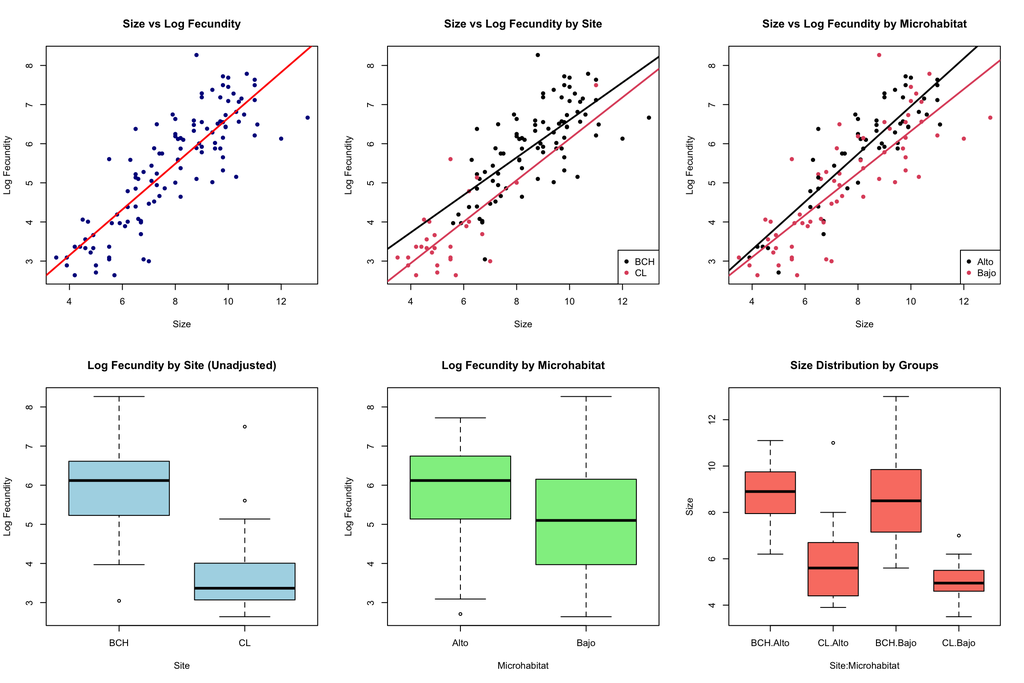

```r
par(mfrow=c(2,3))

# 1. Relationship between covariate and response
plot(size, lnfecund,
     main = "Size vs Log Fecundity",
     xlab = "Size", ylab = "Log Fecundity",
     pch = 16, col = "darkblue")
abline(lm(lnfecund ~ size), col = "red", lwd = 2)

# 2. By site
plot(size, lnfecund, col = as.numeric(site),
     main = "Size vs Log Fecundity by Site",
     xlab = "Size", ylab = "Log Fecundity", pch = 16)
legend("bottomright", levels(site), col = 1:nlevels(site), pch = 16)
# Add regression lines for each site
for(i in 1:nlevels(site)) {
  site_data <- dataf[dataf$site == levels(site)[i], ]
  abline(lm(lnfecund ~ size, data = site_data), col = i, lwd = 2)
}

# 3. By microhabitat
plot(size, lnfecund, col = as.numeric(microhab),
     main = "Size vs Log Fecundity by Microhabitat",
     xlab = "Size", ylab = "Log Fecundity", pch = 16)
legend("bottomright", levels(microhab), col = 1:nlevels(microhab), pch = 16)
for(i in 1:nlevels(microhab)) {
  hab_data <- dataf[dataf$microhab == levels(microhab)[i], ]
  abline(lm(lnfecund ~ size, data = hab_data), col = i, lwd = 2)
}

# 4. Group means (unadjusted)
boxplot(lnfecund ~ site, data = dataf,
        main = "Log Fecundity by Site (Unadjusted)",
        xlab = "Site", ylab = "Log Fecundity",
        col = "lightblue")

# 5. Group means by microhabitat
boxplot(lnfecund ~ microhab, data = dataf,
        main = "Log Fecundity by Microhabitat",
        xlab = "Microhabitat", ylab = "Log Fecundity",
        col = "lightgreen")

# 6. Covariate distribution by groups
boxplot(size ~ site:microhab, data = dataf,
        main = "Size Distribution by Groups",
        xlab = "Site:Microhabitat", ylab = "Size",
        col = "salmon")
```

```r
par(mfrow=c(1,1))
```

### Testing ANCOVA Assumptions

Before conducting ANCOVA, we must test the crucial assumption of homogeneity of regression slopes:

```r
# Test homogeneity of regression slopes
# This tests whether the covariate has the same effect across all groups

# Full model with interactions between covariate and factors
full_model <- lm(lnfecund ~ size * site * microhab, data = dataf)
summary(full_model)
```

```
##
## Call:
## lm(formula = lnfecund ~ size * site * microhab, data = dataf)
##
## Residuals:
##      Min       1Q   Median       3Q      Max
## -1.80762 -0.46788 -0.06438  0.44010  2.50454
##
## Coefficients:
##                        Estimate Std. Error t value Pr(>|t|)
## (Intercept)             1.75235    0.38571   4.543 1.46e-05 ***
## size                    0.42226    0.06263   6.742 8.21e-10 ***
## site.L                 -0.16472    0.54548  -0.302   0.7633
## microhab.L              0.72064    0.54548   1.321   0.1893
## size:site.L            -0.07185    0.08858  -0.811   0.4190
## size:microhab.L        -0.18153    0.08858  -2.049   0.0429 *
## site.L:microhab.L       1.23848    0.77142   1.605   0.1113
## size:site.L:microhab.L -0.22042    0.12527  -1.760   0.0813 .
## ---
## Signif. codes:  0 '***' 0.001 '**' 0.01 '*' 0.05 '.' 0.1 ' ' 1
##
## Residual standard error: 0.7135 on 107 degrees of freedom
## Multiple R-squared:  0.7689, Adjusted R-squared:  0.7538
## F-statistic: 50.87 on 7 and 107 DF,  p-value: < 2.2e-16
```

```r
# Reduced model without covariate interactions
reduced_model <- lm(lnfecund ~ size + site * microhab, data = dataf)
summary(reduced_model)
```

```
##
## Call:
## lm(formula = lnfecund ~ size + site * microhab, data = dataf)
##
## Residuals:
##      Min       1Q   Median       3Q      Max
## -1.77118 -0.44191 -0.05405  0.45863  2.49966
##
## Coefficients:
##                   Estimate Std. Error t value Pr(>|t|)
## (Intercept)        1.50781    0.32527   4.636 9.85e-06 ***
## size               0.47558    0.04426  10.745  < 2e-16 ***
## site.L            -0.48228    0.14929  -3.230  0.00163 **
## microhab.L        -0.29716    0.11541  -2.575  0.01136 *
## site.L:microhab.L  0.11295    0.16215   0.697  0.48752
## ---
## Signif. codes:  0 '***' 0.001 '**' 0.01 '*' 0.05 '.' 0.1 ' ' 1
##
## Residual standard error: 0.7186 on 110 degrees of freedom
## Multiple R-squared:  0.7591, Adjusted R-squared:  0.7503
## F-statistic: 86.64 on 4 and 110 DF,  p-value: < 2.2e-16
```

```r
# Test the assumption using ANOVA
slope_test <- anova(reduced_model, full_model)
print("Test of homogeneity of regression slopes:")
```

```
## [1] "Test of homogeneity of regression slopes:"
```

```r
print(slope_test)
```

```
## Analysis of Variance Table
##
## Model 1: lnfecund ~ size + site * microhab
## Model 2: lnfecund ~ size * site * microhab
##   Res.Df    RSS Df Sum of Sq     F Pr(>F)
## 1    110 56.800
## 2    107 54.473  3    2.3275 1.524 0.2125
```

```r
if(slope_test$`Pr(>F)`[2] > 0.05) {
  print("✓ Assumption of homogeneous slopes is met (p > 0.05)")
  print("We can proceed with ANCOVA")
} else {
  print("✗ Assumption violated - slopes differ significantly across groups")
  print("Consider separate analyses by group or interaction terms")
}
```

```
## [1] "✓ Assumption of homogeneous slopes is met (p > 0.05)"
## [1] "We can proceed with ANCOVA"
```

### Fitting the ANCOVA Model

Now we can fit the ANCOVA:

```r
fecund.lm <- lm(lnfecund ~ size + site * microhab, data = dataf)
fecund.ancova <- Anova(fecund.lm, type = 'III')

summary(fecund.lm)
```

```
##
## Call:
## lm(formula = lnfecund ~ size + site * microhab, data = dataf)
##
## Residuals:
##      Min       1Q   Median       3Q      Max
## -1.77118 -0.44191 -0.05405  0.45863  2.49966
##
## Coefficients:
##                   Estimate Std. Error t value Pr(>|t|)
## (Intercept)        1.50781    0.32527   4.636 9.85e-06 ***
## size               0.47558    0.04426  10.745  < 2e-16 ***
## site.L            -0.48228    0.14929  -3.230  0.00163 **
## microhab.L        -0.29716    0.11541  -2.575  0.01136 *
## site.L:microhab.L  0.11295    0.16215   0.697  0.48752
## ---
## Signif. codes:  0 '***' 0.001 '**' 0.01 '*' 0.05 '.' 0.1 ' ' 1
##
## Residual standard error: 0.7186 on 110 degrees of freedom
## Multiple R-squared:  0.7591, Adjusted R-squared:  0.7503
## F-statistic: 86.64 on 4 and 110 DF,  p-value: < 2.2e-16
```

```r
print("ANCOVA Results:")
```

```
## [1] "ANCOVA Results:"
```

```r
print(fecund.ancova)
```

```
## Anova Table (Type III tests)
##
## Response: lnfecund
##               Sum Sq  Df  F value    Pr(>F)
## (Intercept)   11.096   1  21.4887 9.848e-06 ***
## size          59.618   1 115.4575 < 2.2e-16 ***
## site           5.389   1  10.4356  0.001631 **
## microhab       3.423   1   6.6292  0.011360 *
## site:microhab  0.251   1   0.4852  0.487524
## Residuals     56.800 110
## ---
## Signif. codes:  0 '***' 0.001 '**' 0.01 '*' 0.05 '.' 0.1 ' ' 1
```

Our results show that our covariate (size) has a significant effect on fecundity, along with site and microhabitat. The covariate explains additional variance, making our tests of group differences more powerful.

### Model Diagnostics

Now let’s examine some plots to see how residuals are distributed:

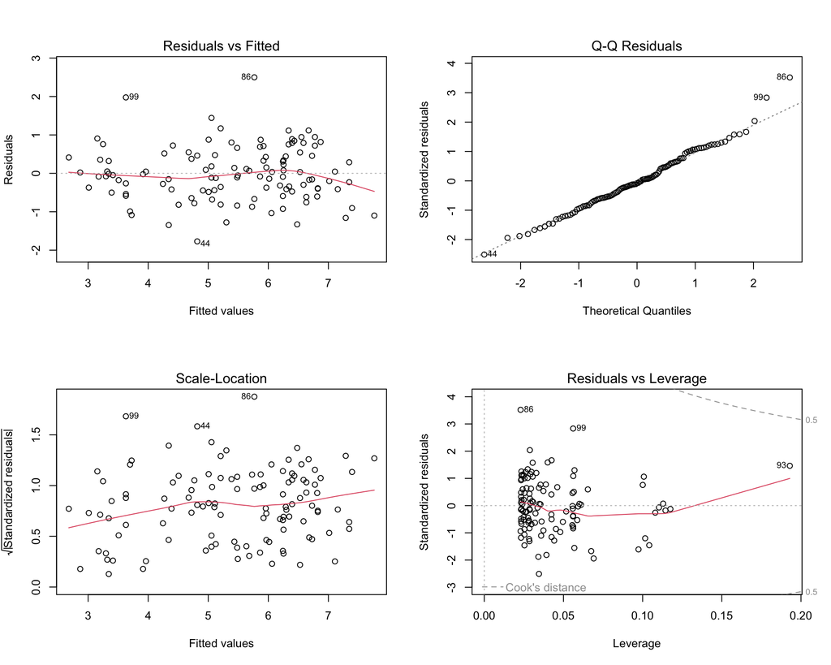

```r
par(mfrow=c(2,2))
plot(fecund.lm)
```

```r
par(mfrow=c(1,1))

# Additional diagnostic tests
print("Normality test of residuals:")
```

```
## [1] "Normality test of residuals:"
```

```r
shapiro.test(residuals(fecund.lm))
```

```
##
##  Shapiro-Wilk normality test
##
## data:  residuals(fecund.lm)
## W = 0.98537, p-value = 0.2469
```

```r
print("Homoscedasticity test:")
```

```
## [1] "Homoscedasticity test:"
```

```r
library(car)
leveneTest(residuals(fecund.lm) ~ site * microhab, data = dataf)
```

```
## Levene's Test for Homogeneity of Variance (center = median)
##        Df F value Pr(>F)
## group   3  1.3202 0.2714
##       111
```

### Adjusted Means and Post-hoc Tests

One of the key benefits of ANCOVA is obtaining adjusted means:

```r
# Calculate adjusted means (least squares means)
library(emmeans)

# Adjusted means for site
site_emmeans <- emmeans(fecund.lm, ~ site)
print("Adjusted means by site (controlling for size):")
```

```
## [1] "Adjusted means by site (controlling for size):"
```

```r
print(site_emmeans)
```

```
##  site emmean     SE  df lower.CL upper.CL
##  BCH    5.59 0.0845 110     5.43     5.76
##  CL     4.91 0.1740 110     4.57     5.26
##
## Results are averaged over the levels of: microhab
## Confidence level used: 0.95
```

```r
# Adjusted means for microhabitat
microhab_emmeans <- emmeans(fecund.lm, ~ microhab)
print("Adjusted means by microhabitat (controlling for size):")
```

```
## [1] "Adjusted means by microhabitat (controlling for size):"
```

```r
print(microhab_emmeans)
```

```
##  microhab emmean    SE  df lower.CL upper.CL
##  Alto       5.46 0.128 110     5.21     5.72
##  Bajo       5.04 0.111 110     4.82     5.26
##
## Results are averaged over the levels of: site
## Confidence level used: 0.95
```

```r
# Pairwise comparisons
print("Pairwise comparisons for site (adjusted):")
```

```
## [1] "Pairwise comparisons for site (adjusted):"
```

```r
pairs(site_emmeans)
```

```
##  contrast estimate    SE  df t.ratio p.value
##  BCH - CL    0.682 0.211 110   3.230  0.0016
##
## Results are averaged over the levels of: microhab
```

```r
print("Pairwise comparisons for microhabitat (adjusted):")
```

```
## [1] "Pairwise comparisons for microhabitat (adjusted):"
```

```r
pairs(microhab_emmeans)
```

```
##  contrast    estimate    SE  df t.ratio p.value
##  Alto - Bajo     0.42 0.163 110   2.575  0.0114
##
## Results are averaged over the levels of: site
```

```r
# Interaction contrasts
if(fecund.ancova$`Pr(>F)`[4] < 0.05) {
  interaction_emmeans <- emmeans(fecund.lm, ~ site * microhab)
  print("Site × Microhabitat interaction means:")
  print(interaction_emmeans)
}
```

```
## [1] "Site × Microhabitat interaction means:"
##  site microhab emmean    SE  df lower.CL upper.CL
##  BCH  Alto       5.86 0.116 110     5.63     6.09
##  CL   Alto       5.07 0.241 110     4.59     5.54
##  BCH  Bajo       5.33 0.113 110     5.10     5.55
##  CL   Bajo       4.76 0.209 110     4.34     5.17
##
## Confidence level used: 0.95
```

### Effect Sizes for ANCOVA

```r
# Calculate partial eta-squared
ancova_summary <- summary(fecund.lm)
anova_table <- anova(fecund.lm)

# Total sum of squares
ss_total <- sum(anova_table$`Sum Sq`)

# Calculate partial eta-squared for each effect
partial_eta_sq <- anova_table$`Sum Sq` / (anova_table$`Sum Sq` + anova_table$`Sum Sq`[nrow(anova_table)])
names(partial_eta_sq) <- rownames(anova_table)

print("Partial eta-squared (effect sizes):")
```

```
## [1] "Partial eta-squared (effect sizes):"
```

```r
print(partial_eta_sq[-length(partial_eta_sq)]) # Exclude residuals
```

```
##          size          site      microhab site:microhab
##   0.746089763   0.085790088   0.102376865   0.004391984
```

```r
print(paste("R-squared (total variance explained):", round(summary(fecund.lm)$r.squared, 3)))
```

```
## [1] "R-squared (total variance explained): 0.759"
```

```r
print(paste("Adjusted R-squared:", round(summary(fecund.lm)$adj.r.squared, 3)))
```

```
## [1] "Adjusted R-squared: 0.75"
```

### Comparison: ANOVA vs ANCOVA

Let’s compare what happens if we ignore the covariate:

```r
# ANOVA without covariate
anova_only <- lm(lnfecund ~ site * microhab, data = dataf)
anova_results <- Anova(anova_only, type = 'III')

print("Comparison of approaches:")
```

```
## [1] "Comparison of approaches:"
```

```r
print("ANOVA (without covariate):")
```

```
## [1] "ANOVA (without covariate):"
```

```r
print(anova_results)
```

```
## Anova Table (Type III tests)
##
## Response: lnfecund
##                Sum Sq  Df   F value    Pr(>F)
## (Intercept)   1901.26   1 1812.7758 < 2.2e-16 ***
## site            91.39   1   87.1394 1.217e-15 ***
## microhab         9.41   1    8.9743  0.003378 **
## site:microhab    0.08   1    0.0804  0.777350
## Residuals      116.42 111
## ---
## Signif. codes:  0 '***' 0.001 '**' 0.01 '*' 0.05 '.' 0.1 ' ' 1
```

```r
print(paste("R-squared without covariate:", round(summary(anova_only)$r.squared, 3)))
```

```
## [1] "R-squared without covariate: 0.506"
```

```r
print("ANCOVA (with covariate):")
```

```
## [1] "ANCOVA (with covariate):"
```

```r
print(fecund.ancova)
```

```
## Anova Table (Type III tests)
##
## Response: lnfecund
##               Sum Sq  Df  F value    Pr(>F)
## (Intercept)   11.096   1  21.4887 9.848e-06 ***
## size          59.618   1 115.4575 < 2.2e-16 ***
## site           5.389   1  10.4356  0.001631 **
## microhab       3.423   1   6.6292  0.011360 *
## site:microhab  0.251   1   0.4852  0.487524
## Residuals     56.800 110
## ---
## Signif. codes:  0 '***' 0.001 '**' 0.01 '*' 0.05 '.' 0.1 ' ' 1
```

```r
print(paste("R-squared with covariate:", round(summary(fecund.lm)$r.squared, 3)))
```

```
## [1] "R-squared with covariate: 0.759"
```

```r
# Calculate the improvement in explained variance
improvement <- summary(fecund.lm)$r.squared - summary(anova_only)$r.squared
print(paste("Improvement in R-squared by including covariate:", round(improvement, 3)))
```

```
## [1] "Improvement in R-squared by including covariate: 0.253"
```

### Advanced: Multiple Comparisons with ANCOVA

```r
# Comprehensive post-hoc analysis with adjustment for multiple comparisons
contrast_results <- contrast(emmeans(fecund.lm, ~ site * microhab),
                           method = "pairwise",
                           adjust = "tukey")
print("All pairwise comparisons with Tukey adjustment:")
```

```
## [1] "All pairwise comparisons with Tukey adjustment:"
```

```r
print(contrast_results)
```

```
##  contrast            estimate    SE  df t.ratio p.value
##  BCH Alto - CL Alto     0.795 0.279 110   2.847  0.0266
##  BCH Alto - BCH Bajo    0.533 0.154 110   3.455  0.0043
##  BCH Alto - CL Bajo     1.102 0.258 110   4.269  0.0002
##  CL Alto - BCH Bajo    -0.262 0.275 110  -0.951  0.7772
##  CL Alto - CL Bajo      0.307 0.286 110   1.073  0.7068
##  BCH Bajo - CL Bajo     0.569 0.253 110   2.254  0.1155
##
## P value adjustment: tukey method for comparing a family of 4 estimates
```

```r
# Custom contrasts if needed
# Example: compare each site to a control site
if(nlevels(dataf$site) > 2) {
  custom_contrasts <- contrast(emmeans(fecund.lm, ~ site),
                             method = "dunnett")
  print("Comparisons to reference site:")
  print(custom_contrasts)
}
```

## Final thoughts

Repeated measures ANOVA and ANCOVA allow us to conduct more complex ANOVA models by including temporal replication (and overcoming the pseudoreplication problem) and by including continuous covariates to account for such variability in our comparisons.

**Key takeaways:**

### Repeated Measures ANOVA:

- Essential when measurements are taken from the same subjects over time
- Accounts for within-subject correlation and reduces Type I error
- Check sphericity assumption (compound symmetry)
- Consider mixed effects models for more flexibility
- Visualize individual trajectories and interaction patterns

### ANCOVA:

- Combines regression and ANOVA to control for continuous covariates
- **Must check homogeneity of regression slopes** before proceeding
- Provides adjusted means that account for covariate effects
- Increases statistical power by reducing error variance
- Effect sizes help interpret practical significance

### General recommendations:

- Always visualize your data before analysis
- Check model assumptions thoroughly
- Consider effect sizes alongside p-values
- Use appropriate post-hoc tests for multiple comparisons
- Modern mixed effects models often provide more flexibility than traditional approaches

Remember that proper experimental design and consideration of these factors before data collection will lead to more robust and interpretable results.

Licensing Creative Commons License

Licensed under a Creative Commons Attribution-ShareAlike 4.0 International License.  
2026 - Francisco E. Fontúrbel